# Workshop Introduction to R

Forschungskolloq vom 20.02.2020

Patric Eichelberger - patric.eichelberger@bfh.ch

# Allgemeine Anmerkungen

## Dieses Dokument

Dieses Dokument ist ein sogenanntes *R Notebook* und verwendet einerseits [R Markdown](https://rmarkdown.rstudio.com) als Text-Formatierungssyntax in Kombination mit sogannten *Code Chunks*, welche ausführbaren R Code enthalten. Die beiden Begriffe enstanden im Zusammenhang mit [RStudio](https://rstudio.com), mit dem Ziel für Berichte, Text und Datenanalysen in 100% reproduzierbarer Form zu kombinieren. Wird der Bericht erzeugt, werden auch die Daten analysiert und die Resultate von den Berechnungen mit R in den Bericht eingefügt. Darüber hinaus besteht die Möglichkeit den Bericht mittels des Paketes [knitr](https://yihui.org/knitr/) in verschiedene Ausgabeformate wie html oder pdf zu konvertieren. Wir werden uns in diesem Workshop ausschliesslich mit der html-Variante beschäftigen.

## R

R ist im Gegensatz zu kommerziellen Softwarelösungen für statistische Berechnungen, wie z.B. SPSS oder STATA, als eine freie Programmiersprache zu bezeichnen, welche für statistische Berechnungen spezialisiert ist. SPSS und STATA bieten zwar auch Syntax-Varianten als Alternative zur graphischen Benutzeroberfläche, aber haben nur eingeschränkt typische Merkmale einer generellen Programmiersprache (Datentypen, Schleifen, Entscheidungsstrukturen, etc.) und sind an die kommerziellen Softwarepakete gebunden.

R ist sehr mächtig aber kommt in der Basis relativ rudimentär daher. Als konkretes Beispiel sind hier die Visualisierungsmöglichkeiten zu nennen. R kann vieles, aber um wirklich gute und vor allem flexible Visualisierungsmöglichkeiten zu haben ist viel Programmieraufwand nötig. An diesem Punkt kommt der Charakter der freien Software und die grosse Community ins Spiel. Viele Leute standen schon vor den gleichen Problemen und entsprechend gibt es sehr gute Pakete die als freie Erweiterungen zur Verfügung stehen. Um beim Beispiel der Visualisierung zu bleiben, sei hier das Paket [ggplot](https://ggplot2.tidyverse.org/) genannt, welches wir im Folgenden auch verwenden werden. Rund um [RStudio](https://rstudio.com) enstanden viele solcher [Pakete](https://rstudio.com/products/rpackages/) für verschiedenste Anwendungen wie Visualisierung, Datenaufbereitung und -manipulation, Datenimport, etc. Darunter fällt eben auch das zu Beginn genannte [R Markdown](https://rmarkdown.rstudio.com). Eine Sammlung dieser nützlichen Pakete rund um RStudio stellt [tidyverse](https://www.tidyverse.org/) dar, welche wir in diesem Workshop verwenden werden. Dazu gibt es von RStudio viele nützliche [Cheatseets](https://rstudio.com/resources/cheatsheets/), welche eine gute Übersicht bieten und einem die Arbeit erleichtern.

# Pakete laden

Wenn RStudio gestartet wird stehen nur gewisse Basispakete zur Verfügung. Zusätzliche Pakete müssen explizit geladen werden damit diese in der laufenden R-Session verfügbar sind. Eine Übersicht über die aktuell geladenen Pakte liefert:

```r
(.packages())
```

```
## [1] "stats"     "graphics"  "grDevices" "utils"     "datasets"  "methods"
## [7] "base"
```

Zusätzliche Pakete werden geladen mit:

```r
library(tidyverse) # Funktionen für moderne Datenmanipulation und Plotting
library(broom) # Statistische Analyseobjekte in Tidy Tibbles konvertieren
library(mosaic) # Praktsiche Funktion für deskriptive Statistik
```

Wir überprüfen welche Pakete nun geladen sind:

```r
(.packages())
```

```
##  [1] "mosaic"     "Matrix"     "mosaicData" "ggformula"  "ggstance"
##  [6] "lattice"    "broom"      "forcats"    "stringr"    "dplyr"
## [11] "purrr"      "readr"      "tidyr"      "tibble"     "ggplot2"
## [16] "tidyverse"  "stats"      "graphics"   "grDevices"  "utils"
## [21] "datasets"   "methods"    "base"
```

# Daten importieren

Wir behandeln einen Datensatz welcher ebenfalls im Modul *Angewandte Statistik* im BSc Phyisotherapie gebraucht wird. Darin befinden sich von verschiedenen Jahrgängen diverse Messwerte, welche die Studierenden selbst erhoben haben. Wir konzentrieren uns im Folgenden auf die Variablen:

- Geschlecht
- Studienjahrgang
- Huefte.INNEN.Flexion: Hüft-Innenrotation bei gebeugtem Hüftgelenk
- Huefte.INNEN.Extension: Hüft-Innenrotation bei gestrecktem Hüftgelenk
- Huefte.AUSSEN.Flexion: Hüft-Aussenrotation bei gebeugtem Hüftgelenk
- Huefte.AUSSEN.Extension: Hüft-Aussenrotation bei gestrecktem Hüftgelenk

In den meisten Fällen ist unser Forschungszweig wohl mit Daten in *rectangular* Form zu tun. Das heisst, tabellierte Merkmalsausprägungen mit Zeilen und Spalten, wobei eine Zelle einer bestimmten Beobachtung und Variablen einen Wert zuordnet. In unserem Fall beispielsweise ein Winkelwert für die Hüft-Innenroation in Flexion bei einer bestimmten Person. Die [tidyverse](https://www.tidyverse.org/) Kollektion stellt das Paket [readr](https://readr.tidyverse.org/) zur Verfügung um tabellierte Daten aus Textdateien zu lesen und zu schreiben. Es empfiehlt sich generell mit Textdateien zu arbeiten, da diese universell lesbar sind und nicht Drittanbieter Software wie z.B. Excel benötigen. Sollten dennoch Excel-Dateien gelesen werden müssen bietet [tidyverse](https://www.tidyverse.org/) das Paket [readxl](https://readxl.tidyverse.org/). Wir arbeiten im Folgenden mit einer kommaseparierten Textdatei, wobei die Spalten eben durch Kommas getrennt sind.

Die Daten werden mit der Funktion `read_csv` eingelesen, wobei die Spalten `Geschlecht` und `Studienjahrgang` gleich also Faktorvariablen definiert werden. Wir weisen die importierten Daten der Variablen `df`zu, welche den Typ `tibble` hat. Ein Datentyp, der Daten verschiedener Skalenniveaus vereint und als Basis für alle weiteren Analysen dient. Mit dem Befehl `head()` können wir eine Vorschau ausgeben und mit `print()` alle Daten betrachten.

## Hinweis Zuweisungsoperator

Wollen wir einer Variablen einen Wert zuweisen, wird das in Programmiersprachen allgemein mittels Gleichheitszeichen gemacht `myvar = 3`. R hat dafür aber allgemein die Konvention `myvar <- 3`. Da sich der Autor diese Tutorials andere Prgrammiersprachen gewohnt ist, es weniger zu tippen gibt und in R beide Varianten funktionieren, wird das Gleichheitszeichen als Zuweisungsoperator verwendet.

```r
df = read_csv('Exerc_Part4_PHY_Daten.csv', col_types = cols(
  Geschlecht=col_factor(),
  Studienjahrgang=col_factor(levels=NULL)
    )
  )
df$Geschlecht = recode(df$Geschlecht, "0"="m", "1"="f")
head(df) # Vorschau ausgeben
```

```
## # A tibble: 6 x 9
##   code  Geschlecht SprunggelenkM1 SprunggelenkM2 Huefte.INNEN.Fl…
##   <chr> <fct>               <dbl>          <dbl>            <dbl>
## 1 code… m                      15             10               30
## 2 code… m                      24             20               44
## 3 code… m                      26             20               40
## 4 code… m                       8             12               28
## 5 code… m                      51             50               15
## 6 code… m                      10             15               20
## # … with 4 more variables: Huefte.AUSSEN.Flexion <dbl>,
## #   Huefte.INNEN.Extension <dbl>, Huefte.AUSSEN.Extension <dbl>,
## #   Studienjahrgang <fct>
```

```r
print(df) # Inhalt ausgeben
```

```
## # A tibble: 124 x 9
##    code  Geschlecht SprunggelenkM1 SprunggelenkM2 Huefte.INNEN.Fl…
##    <chr> <fct>               <dbl>          <dbl>            <dbl>
##  1 code… m                      15             10               30
##  2 code… m                      24             20               44
##  3 code… m                      26             20               40
##  4 code… m                       8             12               28
##  5 code… m                      51             50               15
##  6 code… m                      10             15               20
##  7 code… m                      80             75               35
##  8 code… m                      12             10               20
##  9 code… m                      50             50               20
## 10 code… m                      52             50               38
## # … with 114 more rows, and 4 more variables: Huefte.AUSSEN.Flexion <dbl>,
## #   Huefte.INNEN.Extension <dbl>, Huefte.AUSSEN.Extension <dbl>,
## #   Studienjahrgang <fct>
```

## Anmerkung zu *tidy* Daten

Im Bereich der Datenwissenschaften und damit auch in R, ist es üblich mit Daten im sogenannten *tidy* (aufgeräumt) Format zu arbeiten. Das heisst, wir haben pro Beobachtung eine Zeile und pro Variable eine Spalte. Das Format wird auch als *long-table* bezeichnet, im Gegensatz zum *wide-table* Ansatz, wie er zum Beispiel in SPSS verwendet wird. Mit Tidy-Daten zu arbeiten bringt nur Vorteile. Man hat einen zentralen Datensatz und muss nicht Zeit damit verschwenden fehleranfällig und von Hand Daten für eine spezifische Analyse zu tabellieren, wie das zum Beispiel für SPSS der Fall ist. SPSS tickt nach dem Schema *eine Zeile pro Person* und Variblen müssen dann enstprechend codert werden. Im vorliegenden Datensatz sind beispielsweise die Variablen `SprunggelenkM1` und `SprunggelenkM2` nicht *tidy*. Die Messwiederholung (M1, M2) ist eine Gruppierungsvariable und sollte nicht im Variablennamen stehen, wie es für SPSS zwingend ist. Wollen wir die beiden *aufräumen* können wir das einfach mit der Funktion `pivot_longer()` aus dem [tidyr](https://tidyr.tidyverse.org/) Paket tun:

```r
tidydf = df %>%
  pivot_longer(cols=starts_with("Sprunggelenk"),names_to = "Rep", values_to = "Sprunggelenk", names_prefix = "Sprunggelenk")
head(tidydf)
```

```
## # A tibble: 6 x 9
##   code  Geschlecht Huefte.INNEN.Fl… Huefte.AUSSEN.F… Huefte.INNEN.Ex…
##   <chr> <fct>                 <dbl>            <dbl>            <dbl>
## 1 code… m                        30               50               25
## 2 code… m                        30               50               25
## 3 code… m                        44               32               42
## 4 code… m                        44               32               42
## 5 code… m                        40               50               38
## 6 code… m                        40               50               38
## # … with 4 more variables: Huefte.AUSSEN.Extension <dbl>,
## #   Studienjahrgang <fct>, Rep <chr>, Sprunggelenk <dbl>
```

Der Datensatz ist jetz nicht mehr korrekt, da sich die Gruppierung in *M1* und *M2* nur auf die Messung am Sprunggelenk bezieht und nicht auf die Messungen an der Hüfte. Dies kommt daher, dass die Messungen die Beantworung unterschiedlicher Fragestellungen zum Ziel hatten. Nämlich einerseits den Einfluss des Faktors Gelenkposition auf die Hüft-Innen- und Aussenrotation und anderseit die Wiederholbarkeit einer Messung am Sprunggelenk. Konsequenterweise müsste man den Datensatz trennen wenn man ihn korrekt in die *tidy* Form bringen möchte. Das einfache Beispiel zeigt wie wichtig es ist sich Gedanken über die Datenstrukturierung im Zusammenhang den vorliegenden Fragestellungen zu machen umd bei der Analyse effizient vorgehen zu können.

Detailliert betrachtet liegen die Daten auch bezüglich der Hüftmessungen noch nicht konsequent in *tidy* Form vor. Denn die tatsächlich gemessene Variable ist immer ein Winkel. Die Attribute in den Variablennamen *Hüfte*, *INNEN/AUSSEN* und *Flexion/Extension* sind eigentlich Gruppierungsvariablen die beschreiben an welchem Gelenk, in welcher Richtung und in welcher Position gemessen wurde und nach denen man nochmals trennen kann. Doch dazu kommen wir später.

Wollten wir etwas ins Wide-Table Format bringen, für den Fall, dass doch noch jemand in SPSS hantieren möchte oder wir sonst Gründe dazu haben, kann mit `pivot_wider` das Gegenteil gemacht werden:

```r
widedf = tidydf %>% pivot_wider(names_from=Rep,values_from=Sprunggelenk,names_prefix="Sprunggelenk")
head(widedf)
```

```
## # A tibble: 6 x 9
##   code  Geschlecht Huefte.INNEN.Fl… Huefte.AUSSEN.F… Huefte.INNEN.Ex…
##   <chr> <fct>                 <dbl>            <dbl>            <dbl>
## 1 code… m                        30               50               25
## 2 code… m                        44               32               42
## 3 code… m                        40               50               38
## 4 code… m                        28               28               32
## 5 code… m                        15               30               15
## 6 code… m                        20               30               40
## # … with 4 more variables: Huefte.AUSSEN.Extension <dbl>,
## #   Studienjahrgang <fct>, SprunggelenkM1 <dbl>, SprunggelenkM2 <dbl>
```

# Beschreibende Statistik

Das in der [tidyverse](https://www.tidyverse.org/) Kollektion enthalte Paket [dplyr](https://dplyr.tidyverse.org/) bietet sehr viele Möglichkeiten für die Datenmanipulation. Darunter verstehen wir zum Beispiel:

- Neue Variablen aus bestehenden Variablen berechnen. Das heisst, zum Beispiel einen Body Mass Index aus Körpergewicht und -grösse zu berechnen. Funktion `mutate()`.
- Bestimmte Variablen (Spalten) auswählen um damit weiter zu arbeiten. Funktion `select()`.
- Bestimmte Beobachtungen (Zeilen) auszuwählen. Das ist praktisch um aus dem Gesamtdatensatz Subsets zu extrahieren. Also zum Beispiel die Männer oder die Frauen. Funktion `filter()`.
- Mehrere Werte zu redzieren. Also zum Beispiel einen Mittelwert berechnen. Funktion `summarise()`.

In einem ersten Schritt benötigen wir die `summarise()` Funktion um nach Subgruppen Summary Statistiken zu berechnen. Wir wollen beispielsweise wissen wie Mittelwert, Median, Standardabweichung, Interquartilsrange, Minimum und Maximum für die verschiedenen Variablen getrennt nach Geschlecht sind.

## Mit Auflistung der Variablen

Wir können die Variablen, für die wir Summary Statistiken berechnen wollen, explizit vorgeben. Hier mal für `Huefte_INNEN_Extension` und `Huefte_AUSSEN_Flexion`.

```r
df %>%
  drop_na(Geschlecht) %>% # Zeilen mit nicht bekanntem Geschlecht entfernen
  group_by(Geschlecht) %>% # Gruppieren nach Geschlecht
  summarise_at(vars(Huefte.INNEN.Extension,Huefte.AUSSEN.Flexion),tibble::lst(mean,sd,median,min,max,IQR), na.rm=T) %>%
  gather(key="key",value="value",-Geschlecht) %>% # Make things tidy
  separate(key, into=c("measurement","statistic"),sep="_") # Separate columns
```

```
## # A tibble: 24 x 4
##    Geschlecht measurement            statistic value
##    <fct>      <chr>                  <chr>     <dbl>
##  1 m          Huefte.INNEN.Extension mean      35.3
##  2 f          Huefte.INNEN.Extension mean      46.9
##  3 m          Huefte.AUSSEN.Flexion  mean      42.0
##  4 f          Huefte.AUSSEN.Flexion  mean      42.2
##  5 m          Huefte.INNEN.Extension sd        10.6
##  6 f          Huefte.INNEN.Extension sd        11.4
##  7 m          Huefte.AUSSEN.Flexion  sd        13.3
##  8 f          Huefte.AUSSEN.Flexion  sd         9.86
##  9 m          Huefte.INNEN.Extension median    35
## 10 f          Huefte.INNEN.Extension median    49
## # … with 14 more rows
```

## Für alle nummerischen Variablen

Wenn wir viele Variablen haben ist es mühsam alle explizit nennen zu müssen um Summary Statistiken berechnen zu können. Wir können auch einfach sagen R solle dies für alle numerischen Variablen tun in wir `summarise_if()` verwenden und mit `is.numeric` die entsprechende Kondition setzen:

```r
statdf = df %>%
  drop_na(Geschlecht) %>% # Zeilen mit nicht bekanntem Geschlecht entfernen
  group_by(Geschlecht) %>% # Gruppieren nach Geschlecht
  summarise_if(is.numeric,funs(mean,sd,median,min,max,IQR), na.rm=T) %>%
  gather(key="key",value="value",-Geschlecht) %>% # Make things tidy
  separate(key, into=c("measurement","statistic"),sep="_") # Separate columns
print(statdf)
```

```
## # A tibble: 72 x 4
##    Geschlecht measurement            statistic value
##    <fct>      <chr>                  <chr>     <dbl>
##  1 m          SprunggelenkM1         mean       44.3
##  2 f          SprunggelenkM1         mean       51.8
##  3 m          SprunggelenkM2         mean       43.5
##  4 f          SprunggelenkM2         mean       51.5
##  5 m          Huefte.INNEN.Flexion   mean       27.6
##  6 f          Huefte.INNEN.Flexion   mean       37.4
##  7 m          Huefte.AUSSEN.Flexion  mean       42.0
##  8 f          Huefte.AUSSEN.Flexion  mean       42.2
##  9 m          Huefte.INNEN.Extension mean       35.3
## 10 f          Huefte.INNEN.Extension mean       46.9
## # … with 62 more rows
```

## Export

In aller Regel wollen wir später für eine Publikation die deskriptiven Statistiken tabellarisch darstellen. Dazu ist es hilfreich die berechneten Werte in einer Textdatei abzuspeichern. Dazu stellt das [readr](https://readr.tidyverse.org/) Paket die Funktionen `write_csv()` und `write_csv2` zur Verfügung. `write_csv2()` unterscheidet sich von `write_csv()` indem es für die Spaltentrennung das Semikolon anstatt des Komma verwendet. Das ist für jene Fälle wo das Komma als Dezimaltrennzeichen verwenet wird und das wiederum ist von den Einstellungen des jeweiligen Betriebssystems abhängig.

```r
write_csv(statdf,"descrStat.csv")
write_csv2(statdf,"descrStat2.csv")
```

## Alternative für die deskriptive Statistik

Es muss nicht zwingend nach dem tidyverse Konzept vorgegangen werden. Das Paket `mosaic` bietet mit der Funktion `favstats()` ebenfalls eine gute Variante um gruppierte Summary-Statistiken zu berechnen, wobei hier nicht mit einem Befehl mehrere Variablen behandelt werden können.

```r
favstats(df$Huefte.AUSSEN.Extension ~ df$Geschlecht)
```

```
##   df$Geschlecht min   Q1 median   Q3 max     mean       sd  n missing
## 1             m  25 35.5     45 45.0  55 40.95652 8.519914 23       0
## 2             f  15 35.0     40 46.5  75 42.00000 9.971601 68       3
```

```r
favstats(df$Huefte.AUSSEN.Flexion ~ df$Geschlecht)
```

```
##   df$Geschlecht min   Q1 median Q3 max     mean        sd  n missing
## 1             m  24 30.0     40 50  70 42.04348 13.309184 23       0
## 2             f  15 39.5     40 50  62 42.22059  9.859983 68       3
```

```r
favstats(df$Huefte.INNEN.Extension ~ df$Geschlecht)
```

```
##   df$Geschlecht min    Q1 median Q3 max     mean       sd  n missing
## 1             m  13 30.00     35 41  55 35.34783 10.58991 23       0
## 2             f  25 38.75     49 55  72 46.88235 11.41684 68       3
```

```r
favstats(df$Huefte.INNEN.Flexion ~ df$Geschlecht)
```

```
##   df$Geschlecht min Q1 median Q3 max     mean       sd  n missing
## 1             m  10 20     28 35  55 27.56522 11.24854 23       0
## 2             f  10 30     38 45  66 37.42647 11.71848 68       3
```

## Visualisierung

Meistens sagen Grafiken mehr als Zahlen und dafür stellt das Paket [ggplot](https://ggplot2.tidyverse.org/) extrem starke Werkzeuge bereit, die es ermöglichlen mit sehr wenig Aufwand publikationsfertige Visualisierungen zu erzeugen.

Wir möchten nun also zum Bespiel für alle Variablen, wiederum getrennt nach Geschlecht, Boxplots zeichnen. Damit das in der Art und Weise von *ggplot* geht brauchen wir den Datensatz nun konsequent im *tidy* Format. Wir haben vorhin gesehen, dass wir den Datensatz nach den Hüft- und Sprunggelenkmessungen trennen müssen damit dies geht und zudem die Attribute *Hüfte*, *INNEN/AUSSEN* und *Flexion/Extension* in den Variablennamen als Gruppierungsvariablen behandelt werden müssen.

Wir splitten den Datensatz zuerst auf in `hipdf` für die Hüfte und `ankledf` für die Sprunggelenkmessungen:

```r
hipdf = df %>% select(-c("SprunggelenkM1","SprunggelenkM2"))
ankledf = df %>% select(-c("Huefte.INNEN.Extension","Huefte.INNEN.Flexion","Huefte.AUSSEN.Extension","Huefte.AUSSEN.Flexion"))
```

Nun bringen wir die Hüftmessungen noch konsequent ins *tidy* Format:

```r
thipdf = hipdf %>%
  pivot_longer(cols=starts_with("Huefte"),names_to = "Condition", values_to = "Winkel") %>%
  separate(Condition,into = c("Gelenk","Richtung","Stellung"),sep = "[.]")
print(thipdf)
```

```
## # A tibble: 496 x 7
##    code      Geschlecht Studienjahrgang Gelenk Richtung Stellung  Winkel
##    <chr>     <fct>      <fct>           <chr>  <chr>    <chr>      <dbl>
##  1 code01.01 m          PT05            Huefte INNEN    Flexion       30
##  2 code01.01 m          PT05            Huefte AUSSEN   Flexion       50
##  3 code01.01 m          PT05            Huefte INNEN    Extension     25
##  4 code01.01 m          PT05            Huefte AUSSEN   Extension     40
##  5 code01.02 m          PT05            Huefte INNEN    Flexion       44
##  6 code01.02 m          PT05            Huefte AUSSEN   Flexion       32
##  7 code01.02 m          PT05            Huefte INNEN    Extension     42
##  8 code01.02 m          PT05            Huefte AUSSEN   Extension     36
##  9 code01.03 m          PT05            Huefte INNEN    Flexion       40
## 10 code01.03 m          PT05            Huefte AUSSEN   Flexion       50
## # … with 486 more rows
```

Nun können wir die Funktionaliäten von *ggplot* voll ausschöpfen:

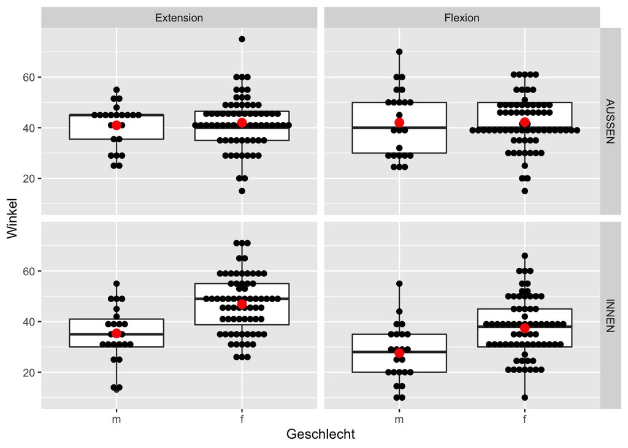

```r
thipdf %>%
  drop_na(Geschlecht) %>% # Zeilen mit nicht bekanntem Geschlecht entfernen
  ggplot(aes(x=Geschlecht,y=Winkel)) + # Vorgaben was auf x- und y-Achse geplottet werden soll
  geom_boxplot() + # Hinzufügen des Boxplots
  geom_dotplot(binaxis = 'y', stackdir = 'center', position = 'dodge') + # Hinzfügen der Datenpunkte
  stat_summary(geom = "point", fun.y = "mean", col = "red", size = 3) + # Mittelwert
  facet_grid(rows = vars(Richtung), cols = vars(Stellung)) # Gruppieren
```

# Schliessende Statistik

## Paired samples: Vergleich Innenrotation Flexion vs. Extension

Um zu entscheiden welcher statistische angewendet werden darf müssen wir nochmals einen Blick auf die Stichprobengrössen werfen. Zuerst wählen wir und die Daten aus unserem Datensatz aus für die wir uns jetzt interessieren:

```r
analysisdf = thipdf %>%
  filter(Richtung=="INNEN" & Stellung=="Flexion" | Richtung=="INNEN" & Stellung=="Extension")
print(analysisdf)
```

```
## # A tibble: 248 x 7
##    code      Geschlecht Studienjahrgang Gelenk Richtung Stellung  Winkel
##    <chr>     <fct>      <fct>           <chr>  <chr>    <chr>      <dbl>
##  1 code01.01 m          PT05            Huefte INNEN    Flexion       30
##  2 code01.01 m          PT05            Huefte INNEN    Extension     25
##  3 code01.02 m          PT05            Huefte INNEN    Flexion       44
##  4 code01.02 m          PT05            Huefte INNEN    Extension     42
##  5 code01.03 m          PT05            Huefte INNEN    Flexion       40
##  6 code01.03 m          PT05            Huefte INNEN    Extension     38
##  7 code01.04 m          PT05            Huefte INNEN    Flexion       28
##  8 code01.04 m          PT05            Huefte INNEN    Extension     32
##  9 code01.05 m          PT05            Huefte INNEN    Flexion       15
## 10 code01.05 m          PT05            Huefte INNEN    Extension     15
## # … with 238 more rows
```

Jetz schauen wir uns mal die Stichprobengrössen an:

```r
analysisdf %>%
  group_by(Geschlecht,Stellung) %>%
  count() %>% print()
```

```
## # A tibble: 6 x 3
## # Groups:   Geschlecht, Stellung [6]
##   Geschlecht Stellung      n
##   <fct>      <chr>     <int>
## 1 m          Extension    23
## 2 m          Flexion      23
## 3 f          Extension    71
## 4 f          Flexion      71
## 5 <NA>       Extension    30
## 6 <NA>       Flexion      30
```

Wie wir sehen gibt es noch 30 Zeilen ohne definiertes Geschlecht. Diese löschen wir also noch raus:

```r
analysisdf = analysisdf %>%
  drop_na(Geschlecht)
print(analysisdf)
```

```
## # A tibble: 188 x 7
##    code      Geschlecht Studienjahrgang Gelenk Richtung Stellung  Winkel
##    <chr>     <fct>      <fct>           <chr>  <chr>    <chr>      <dbl>
##  1 code01.01 m          PT05            Huefte INNEN    Flexion       30
##  2 code01.01 m          PT05            Huefte INNEN    Extension     25
##  3 code01.02 m          PT05            Huefte INNEN    Flexion       44
##  4 code01.02 m          PT05            Huefte INNEN    Extension     42
##  5 code01.03 m          PT05            Huefte INNEN    Flexion       40
##  6 code01.03 m          PT05            Huefte INNEN    Extension     38
##  7 code01.04 m          PT05            Huefte INNEN    Flexion       28
##  8 code01.04 m          PT05            Huefte INNEN    Extension     32
##  9 code01.05 m          PT05            Huefte INNEN    Flexion       15
## 10 code01.05 m          PT05            Huefte INNEN    Extension     15
## # … with 178 more rows
```

Nun haben wir nur noch Zeilen mit definiertem Geschlecht. Nun kann es aber noch sein, dass in einer Zeile mit definiertem Geschlecht Winkelmessungen fehlen. Wir überprüfen das ebenfalls:

```r
analysisdf %>%
  group_by(Geschlecht,Stellung) %>%
  summarise(non_na_count = sum(!is.na(Winkel)),
            na_count = sum(is.na(Winkel)))
```

```
## # A tibble: 4 x 4
## # Groups:   Geschlecht [2]
##   Geschlecht Stellung  non_na_count na_count
##   <fct>      <chr>            <int>    <int>
## 1 m          Extension           23        0
## 2 m          Flexion             23        0
## 3 f          Extension           68        3
## 4 f          Flexion             68        3
```

Bei den Frauen fallen nochmals drei Werte raus, welche wir vor der weiteren Analyse entfernen:

```r
analysisdf = analysisdf %>% drop_na()
analysisdf %>%
  group_by(Geschlecht,Stellung) %>%
  summarise(non_na_count = sum(!is.na(Winkel)),
            na_count = sum(is.na(Winkel)))
```

```
## # A tibble: 4 x 4
## # Groups:   Geschlecht [2]
##   Geschlecht Stellung  non_na_count na_count
##   <fct>      <chr>            <int>    <int>
## 1 m          Extension           23        0
## 2 m          Flexion             23        0
## 3 f          Extension           68        0
## 4 f          Flexion             68        0
```

Wir haben also Werte von 23 Männern und 68 Frauen. Bei diesen Stichprobenumfängen sollten wir nicht von Normalverteilung ausgehen sollten uns aber auch nicht unbedingt auf einen Test auf Normalverteilung verlassen weil bei den Männern weniger als 30 Werte vorhanden sind. Beispielhalber zeigen wir aber trotzdem wie wir uns das Histogramm und den QQ-Plot anschauen und wie wir den Shapiro-Wilk Test für die Prüfung der Normalverteilung anwenden.

## Histogramm

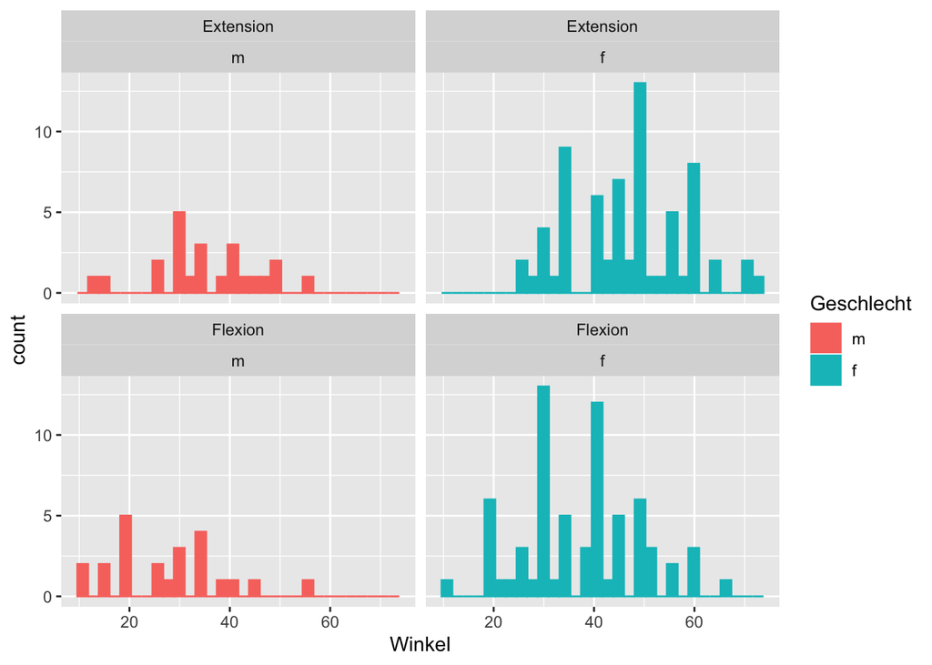

```r
ggplot(analysisdf, aes(x=Winkel, color=Geschlecht, fill=Geschlecht)) +
  geom_histogram() +
  facet_wrap(vars(Stellung,Geschlecht))
```

## QQ-Plot

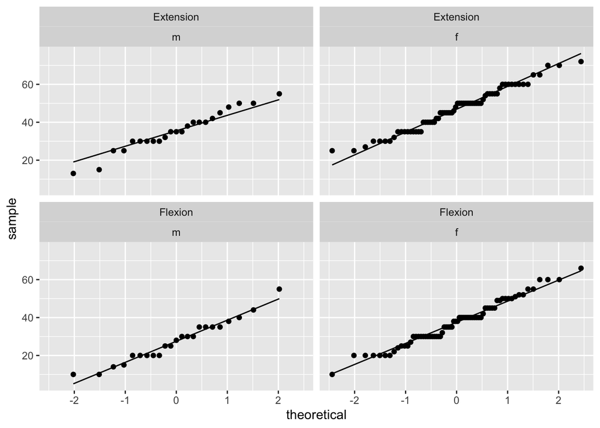

```r
ggplot(analysisdf, aes(sample=Winkel)) +
  geom_qq() +
  geom_qq_line() +
  facet_wrap(vars(Stellung,Geschlecht))
```

## Shapiro Wilk Test

Wir demonstrieren zuerst den konservativen Weg:

```r
tmpdf = filter(analysisdf,Geschlecht=="m" & Stellung=="Flexion") # Subset extrahieren
print(tmpdf)
```

```
## # A tibble: 23 x 7
##    code      Geschlecht Studienjahrgang Gelenk Richtung Stellung Winkel
##    <chr>     <fct>      <fct>           <chr>  <chr>    <chr>     <dbl>
##  1 code01.01 m          PT05            Huefte INNEN    Flexion      30
##  2 code01.02 m          PT05            Huefte INNEN    Flexion      44
##  3 code01.03 m          PT05            Huefte INNEN    Flexion      40
##  4 code01.04 m          PT05            Huefte INNEN    Flexion      28
##  5 code01.05 m          PT05            Huefte INNEN    Flexion      15
##  6 code01.06 m          PT05            Huefte INNEN    Flexion      20
##  7 code01.07 m          PT05            Huefte INNEN    Flexion      35
##  8 code01.08 m          PT05            Huefte INNEN    Flexion      20
##  9 code01.09 m          PT05            Huefte INNEN    Flexion      20
## 10 code01.10 m          PT05            Huefte INNEN    Flexion      38
## # … with 13 more rows
```

```r
shapiro.test(tmpdf$Winkel) # Shapiro Wilk Test auf den Winkel anwenden
```

```
##
##  Shapiro-Wilk normality test
##
## data:  tmpdf$Winkel
## W = 0.96416, p-value = 0.5523
```

Nun ist es etwas mühsam diese Code Zeilen zu wiederholen. Insgesamt müssten wird das vier mal tun. Nämlich für alle Kombinationen für m/f - Flexion/Extension. Auch für diesen Fall stellt die [tidyverse](https://www.tidyverse.org/) Kollektion entsprechende Werkzeuge bereit um die gleich Operation auf mehrere Gruppen anzuwenden.

```r
analysisdf %>%
  group_by(Geschlecht,Stellung) %>%
  do(tidy(shapiro.test(.$Winkel)))
```

```
## # A tibble: 4 x 5
## # Groups:   Geschlecht, Stellung [4]
##   Geschlecht Stellung  statistic p.value method
##   <fct>      <chr>         <dbl>   <dbl> <chr>
## 1 m          Extension     0.970   0.694 Shapiro-Wilk normality test
## 2 m          Flexion       0.964   0.552 Shapiro-Wilk normality test
## 3 f          Extension     0.974   0.169 Shapiro-Wilk normality test
## 4 f          Flexion       0.978   0.261 Shapiro-Wilk normality test
```

Wir stellen für keine der Subgruppen signifikante Abweichung von der Normalverteilung ist. Wir müssen natürlich im Kopf behalten, dass die Aussage für die Männer zweifelhaft ist, weil wir nur eine Stichprobengrösse von 23 haben. Sicherheitshalber sollten wir in diesem Fall nicht-parametrisch testen. Zu Demonstrationszwecken testen wir nun parametrisch und nicht-parametrisch.

Wir können es wiederum auf den konservativen Weg tun:

```r
adf = filter(analysisdf,Geschlecht=="m" & Stellung=="Flexion") # Subset A extrahieren
bdf = filter(analysisdf,Geschlecht=="m" & Stellung=="Extension") # Subset B extrahieren
print(tmpdf)
```

```
## # A tibble: 23 x 7
##    code      Geschlecht Studienjahrgang Gelenk Richtung Stellung Winkel
##    <chr>     <fct>      <fct>           <chr>  <chr>    <chr>     <dbl>
##  1 code01.01 m          PT05            Huefte INNEN    Flexion      30
##  2 code01.02 m          PT05            Huefte INNEN    Flexion      44
##  3 code01.03 m          PT05            Huefte INNEN    Flexion      40
##  4 code01.04 m          PT05            Huefte INNEN    Flexion      28
##  5 code01.05 m          PT05            Huefte INNEN    Flexion      15
##  6 code01.06 m          PT05            Huefte INNEN    Flexion      20
##  7 code01.07 m          PT05            Huefte INNEN    Flexion      35
##  8 code01.08 m          PT05            Huefte INNEN    Flexion      20
##  9 code01.09 m          PT05            Huefte INNEN    Flexion      20
## 10 code01.10 m          PT05            Huefte INNEN    Flexion      38
## # … with 13 more rows
```

```r
t.test(adf$Winkel,bdf$Winkel,paired = T) # Shapiro Wilk Test auf den Winkel anwenden
```

```
##
##  Paired t-test
##
## data:  adf$Winkel and bdf$Winkel
## t = -3.4696, df = 22, p-value = 0.002177
## alternative hypothesis: true difference in means is not equal to 0
## 95 percent confidence interval:
##  -12.434491  -3.130727
## sample estimates:
## mean of the differences
##               -7.782609
```

Für den Vergleich bei den Frauen müssten wir ja den obigen Code wiederholen. Das ist ineffizient und wir können ähnlich vorhin beim Normalitätstest vorgehen:

```r
analysisdf %>%
  group_by(Geschlecht) %>%
  do(tidy(t.test(Winkel ~ Stellung, data=., paired=T)))
```

```
## # A tibble: 2 x 9
## # Groups:   Geschlecht [2]
##   Geschlecht estimate statistic  p.value parameter conf.low conf.high
##   <fct>         <dbl>     <dbl>    <dbl>     <dbl>    <dbl>     <dbl>
## 1 m              7.78      3.47 2.18e- 3        22     3.13      12.4
## 2 f              9.46      7.29 4.62e-10        67     6.87      12.0
## # … with 2 more variables: method <chr>, alternative <chr>
```

## Two samples: Vergleich Innenrotation in Flexion und Extension zwischen Männern und Frauen

Die Impelemtierung dieses statistischen Vergleiches ist nun den Teilnehmenden überlassen.